# Notebook

# Step 8: Review Plume Height Estimates

## Purpose:

- Offers an immediate review of the plume height results for quality control and interpretation.

```python
mer_results.columns
```

```
Index(['TEM_kg', 'MERPercentile_5', 'MERPercentile_10', 'MERPercentile_15',
       'MERPercentile_20', 'MERPercentile_25', 'MERPercentile_30',
       'MERPercentile_35', 'MERPercentile_40', 'MERPercentile_45',
       'MERPercentile_50', 'MERPercentile_55', 'MERPercentile_60',
       'MERPercentile_65', 'MERPercentile_70', 'MERPercentile_75',
       'MERPercentile_80', 'MERPercentile_85', 'MERPercentile_90',
       'MERPercentile_95', '90%_interpercentile_MERrange_kg/s',
       'Duration_hr_P5', 'Duration_hr_P10', 'Duration_hr_P15',
       'Duration_hr_P20', 'Duration_hr_P25', 'Duration_hr_P30',
       'Duration_hr_P35', 'Duration_hr_P40', 'Duration_hr_P45',
       'Duration_hr_P50', 'Duration_hr_P55', 'Duration_hr_P60',
       'Duration_hr_P65', 'Duration_hr_P70', 'Duration_hr_P75',
       'Duration_hr_P80', 'Duration_hr_P85', 'Duration_hr_P90',
       'Duration_hr_P95', 'Duration_hr_90%_interpercentile', 'VEI'],
      dtype='object')
```

```python
heights['VEI']=mer_results['VEI']
# List of columns to be assigned
columns_to_assign = ['Duration_hr_P5', 'Duration_hr_P25', 'Duration_hr_P50', 'Duration_hr_P75', 'Duration_hr_P95', 'Duration_hr_90%_interpercentile'] #'Duration_hr_best_estimate_Uncertainty'

# Assign values from mer_results to heights for these columns
heights[columns_to_assign] = mer_results[columns_to_assign]



heights.to_csv('Final_prediction_results.csv')

heights
```

|  | MER_kg/s | HeightPercentile_5 | HeightPercentile_10 | HeightPercentile_15 | HeightPercentile_20 | HeightPercentile_25 | HeightPercentile_30 | HeightPercentile_35 | HeightPercentile_40 | HeightPercentile_45 | ... | HeightPercentile_90 | HeightPercentile_95 | 90%_interpercentile_Height_range_km | VEI | Duration_hr_P5 | Duration_hr_P25 | Duration_hr_P50 | Duration_hr_P75 | Duration_hr_P95 | Duration_hr_90%_interpercentile |
| --- | --- | --- | --- | --- | --- | --- | --- | --- | --- | --- | --- | --- | --- | --- | --- | --- | --- | --- | --- | --- | --- |
| 0 | 2.637347e+08 | 20.915370 | 21.331430 | 21.613819 | 21.846972 | 22.059058 | 22.246575 | 22.423805 | 22.583176 | 22.732437 | ... | 24.544383 | 25.037020 | 4.121650 | 2 | 451.148534 | 22.069162 | 18.531088 | 15.088152 | 0.802784 | 0.804215 |
| 1 | 1.416006e+09 | 28.241585 | 28.951933 | 29.411540 | 29.818273 | 30.170567 | 30.480591 | 30.770946 | 31.029136 | 31.307137 | ... | 34.440346 | 35.253662 | 7.012077 | 3 | 1445.341002 | 52.417107 | 42.635834 | 30.553609 | 1.495757 | 1.497307 |
| 2 | 7.603739e+09 | 38.076356 | 39.267137 | 39.994580 | 40.693994 | 41.252351 | 41.756176 | 42.223867 | 42.638044 | 43.116196 | ... | 48.301666 | 49.731648 | 11.655293 | 4 | 4628.288861 | 128.057035 | 96.568842 | 63.982951 | 2.784014 | 2.785689 |
| 3 | 4.087218e+10 | 51.375579 | 53.282612 | 54.406904 | 55.483776 | 56.427325 | 57.193282 | 57.927141 | 58.647137 | 59.370243 | ... | 67.818301 | 70.117453 | 18.741874 | 5 | 14822.270572 | 312.278345 | 218.349011 | 139.006366 | 5.177730 | 5.179540 |

4 rows × 28 columns

```python
# Add a bold title using Styler
styled_table = heights.style.set_caption("<b>VEI and Related Data</b>")
styled_table
```

**VEI and Related Data**

|  | MER_kg/s | HeightPercentile_5 | HeightPercentile_10 | HeightPercentile_15 | HeightPercentile_20 | HeightPercentile_25 | HeightPercentile_30 | HeightPercentile_35 | HeightPercentile_40 | HeightPercentile_45 | HeightPercentile_50 | HeightPercentile_55 | HeightPercentile_60 | HeightPercentile_65 | HeightPercentile_70 | HeightPercentile_75 | HeightPercentile_80 | HeightPercentile_85 | HeightPercentile_90 | HeightPercentile_95 | 90%_interpercentile_Height_range_km | VEI | Duration_hr_P5 | Duration_hr_P25 | Duration_hr_P50 | Duration_hr_P75 | Duration_hr_P95 | Duration_hr_90%_interpercentile |
| --- | --- | --- | --- | --- | --- | --- | --- | --- | --- | --- | --- | --- | --- | --- | --- | --- | --- | --- | --- | --- | --- | --- | --- | --- | --- | --- | --- | --- |
| 0 | 263734738.339319 | 20.915370 | 21.331430 | 21.613819 | 21.846972 | 22.059058 | 22.246575 | 22.423805 | 22.583176 | 22.732437 | 22.895094 | 23.057809 | 23.210690 | 23.387119 | 23.556670 | 23.740064 | 23.975067 | 24.233409 | 24.544383 | 25.037020 | 4.121650 | 2 | 451.148534 | 22.069162 | 18.531088 | 15.088152 | 0.802784 | 0.804215 |
| 1 | 1416005871.096091 | 28.241585 | 28.951933 | 29.411540 | 29.818273 | 30.170567 | 30.480591 | 30.770946 | 31.029136 | 31.307137 | 31.583728 | 31.858484 | 32.126473 | 32.404716 | 32.709332 | 33.020670 | 33.418236 | 33.880200 | 34.440346 | 35.253662 | 7.012077 | 3 | 1445.341002 | 52.417107 | 42.635834 | 30.553609 | 1.495757 | 1.497307 |
| 2 | 7603738971.918003 | 38.076356 | 39.267137 | 39.994580 | 40.693994 | 41.252351 | 41.756176 | 42.223867 | 42.638044 | 43.116196 | 43.576116 | 44.022723 | 44.458900 | 44.939674 | 45.432922 | 45.952393 | 46.605362 | 47.372896 | 48.301666 | 49.731648 | 11.655293 | 4 | 4628.288861 | 128.057035 | 96.568842 | 63.982951 | 2.784014 | 2.785689 |
| 3 | 40872184089.891838 | 51.375579 | 53.282612 | 54.406904 | 55.483776 | 56.427325 | 57.193282 | 57.927141 | 58.647137 | 59.370243 | 60.101794 | 60.855017 | 61.544015 | 62.330858 | 63.091283 | 63.932874 | 65.033164 | 66.275561 | 67.818301 | 70.117453 | 18.741874 | 5 | 14822.270572 | 312.278345 | 218.349011 | 139.006366 | 5.177730 | 5.179540 |

```python
from rich.console import Console
from rich.table import Table

# Ensure VEI is first
if "VEI" not in heights.columns:
    raise KeyError("The 'VEI' column is missing from the DataFrame.")

cols = ["VEI"] + [col for col in heights.columns if col != "VEI"]
heights = heights[cols]

# Rich Console for better formatting
console = Console()

# Function to print DataFrame in chunks of six columns, keeping VEI first
def print_six_columns_with_vei_first(df):
    num_cols = len(df.columns)
    for i in range(1, num_cols, 3):  # 5 because VEI is fixed
        # Slice five columns at a time, after the first column
        cols = ["VEI"] + list(df.columns[i:i+3])

        # Create a table for this chunk
        table = Table(title="VEI and Related Data")
        for col in cols:
            table.add_column(col, justify="center")

        # Add rows to the table
        for _, row in df[cols].iterrows():
            table.add_row(*[str(cell) for cell in row])

        # Print the table
        console.print(table)

# Display the DataFrame
print_six_columns_with_vei_first(heights)
```

```
                         VEI and Related Data
┏━━━━━┳━━━━━━━━━━━━━━━━━━━━┳━━━━━━━━━━━━━━━━━━━━┳━━━━━━━━━━━━━━━━━━━━━┓
┃ VEI ┃      MER_kg/s      ┃ HeightPercentile_5 ┃ HeightPercentile_10 ┃
┡━━━━━╇━━━━━━━━━━━━━━━━━━━━╇━━━━━━━━━━━━━━━━━━━━╇━━━━━━━━━━━━━━━━━━━━━┩
│ 2.0 │ 263734738.33931884 │ 20.915369546884616 │ 21.331429911766858  │
│ 3.0 │ 1416005871.0960913 │ 28.241585300901246 │ 28.951933087831016  │
│ 4.0 │ 7603738971.918003  │ 38.076355785647905 │  39.26713707196505  │
│ 5.0 │ 40872184089.89184  │  51.3755789018824  │  53.28261213731151  │
└─────┴────────────────────┴────────────────────┴─────────────────────┘
```

```
                          VEI and Related Data
┏━━━━━┳━━━━━━━━━━━━━━━━━━━━━┳━━━━━━━━━━━━━━━━━━━━━┳━━━━━━━━━━━━━━━━━━━━━┓
┃ VEI ┃ HeightPercentile_15 ┃ HeightPercentile_20 ┃ HeightPercentile_25 ┃
┡━━━━━╇━━━━━━━━━━━━━━━━━━━━━╇━━━━━━━━━━━━━━━━━━━━━╇━━━━━━━━━━━━━━━━━━━━━┩
│ 2.0 │ 21.613819391639456  │  21.84697161894229  │ 22.059057606035502  │
│ 3.0 │ 29.411540437974523  │  29.81827314889459  │  30.17056664361438  │
│ 4.0 │  39.99457973600822  │  40.69399355593317  │  41.25235061535111  │
│ 5.0 │  54.40690431501138  │  55.48377603870605  │  56.42732532401312  │
└─────┴─────────────────────┴─────────────────────┴─────────────────────┘
```

```
                          VEI and Related Data
┏━━━━━┳━━━━━━━━━━━━━━━━━━━━━┳━━━━━━━━━━━━━━━━━━━━━┳━━━━━━━━━━━━━━━━━━━━━┓
┃ VEI ┃ HeightPercentile_30 ┃ HeightPercentile_35 ┃ HeightPercentile_40 ┃
┡━━━━━╇━━━━━━━━━━━━━━━━━━━━━╇━━━━━━━━━━━━━━━━━━━━━╇━━━━━━━━━━━━━━━━━━━━━┩
│ 2.0 │ 22.246575114862893  │  22.42380470257502  │ 22.583176414439016  │
│ 3.0 │ 30.480590876761344  │  30.77094562365109  │ 31.029135834526937  │
│ 4.0 │  41.75617598951781  │  42.22386736536354  │  42.63804386288488  │
│ 5.0 │  57.19328215742592  │  57.92714138033494  │ 58.647136971993596  │
└─────┴─────────────────────┴─────────────────────┴─────────────────────┘
```

```
                          VEI and Related Data
┏━━━━━┳━━━━━━━━━━━━━━━━━━━━━┳━━━━━━━━━━━━━━━━━━━━━┳━━━━━━━━━━━━━━━━━━━━━┓
┃ VEI ┃ HeightPercentile_45 ┃ HeightPercentile_50 ┃ HeightPercentile_55 ┃
┡━━━━━╇━━━━━━━━━━━━━━━━━━━━━╇━━━━━━━━━━━━━━━━━━━━━╇━━━━━━━━━━━━━━━━━━━━━┩
│ 2.0 │ 22.732436772142417  │ 22.895094282778047  │ 23.057808700834116  │
│ 3.0 │  31.30713665639755  │ 31.583727871348618  │ 31.858484018109245  │
│ 4.0 │  43.11619637338617  │  43.57611610958067  │ 44.022723092844224  │
│ 5.0 │  59.37024344739864  │  60.10179441562113  │  60.85501749374209  │
└─────┴─────────────────────┴─────────────────────┴─────────────────────┘
```

```
                          VEI and Related Data
┏━━━━━┳━━━━━━━━━━━━━━━━━━━━━┳━━━━━━━━━━━━━━━━━━━━━┳━━━━━━━━━━━━━━━━━━━━━┓
┃ VEI ┃ HeightPercentile_60 ┃ HeightPercentile_65 ┃ HeightPercentile_70 ┃
┡━━━━━╇━━━━━━━━━━━━━━━━━━━━━╇━━━━━━━━━━━━━━━━━━━━━╇━━━━━━━━━━━━━━━━━━━━━┩
│ 2.0 │ 23.210689842837628  │  23.38711907299264  │ 23.556670431727383  │
│ 3.0 │ 32.126472858206355  │  32.40471585358821  │  32.70933202652877  │
│ 4.0 │  44.45889992344718  │  44.9396743140395   │  45.43292225100868  │
│ 5.0 │ 61.544014895480494  │  62.33085820499958  │  63.09128261246717  │
└─────┴─────────────────────┴─────────────────────┴─────────────────────┘
```

```
                          VEI and Related Data
┏━━━━━┳━━━━━━━━━━━━━━━━━━━━━┳━━━━━━━━━━━━━━━━━━━━━┳━━━━━━━━━━━━━━━━━━━━━┓
┃ VEI ┃ HeightPercentile_75 ┃ HeightPercentile_80 ┃ HeightPercentile_85 ┃
┡━━━━━╇━━━━━━━━━━━━━━━━━━━━━╇━━━━━━━━━━━━━━━━━━━━━╇━━━━━━━━━━━━━━━━━━━━━┩
│ 2.0 │  23.74006439707223  │ 23.975066627420354  │ 24.233408623387593  │
│ 3.0 │  33.02066981132512  │  33.41823569886797  │  33.88019987500591  │
│ 4.0 │ 45.952392748571384  │  46.6053622940062   │ 47.372896412347515  │
│ 5.0 │ 63.932873853739785  │  65.03316438470173  │  66.27556073642538  │
└─────┴─────────────────────┴─────────────────────┴─────────────────────┘
```

```
                                  VEI and Related Data
┏━━━━━┳━━━━━━━━━━━━━━━━━━━━━┳━━━━━━━━━━━━━━━━━━━━━┳━━━━━━━━━━━━━━━━━━━━━━━━━━━━━━━━━━━━━┓
┃ VEI ┃ HeightPercentile_90 ┃ HeightPercentile_95 ┃ 90%_interpercentile_Height_range_km ┃
┡━━━━━╇━━━━━━━━━━━━━━━━━━━━━╇━━━━━━━━━━━━━━━━━━━━━╇━━━━━━━━━━━━━━━━━━━━━━━━━━━━━━━━━━━━━┩
│ 2.0 │ 24.544383099325774  │  25.03701982289551  │          4.121650276010893          │
│ 3.0 │  34.44034604949838  │  35.25366217166669  │          7.012076870765444          │
│ 4.0 │ 48.301665797482215  │  49.73164840773057  │         11.655292622082662          │
│ 5.0 │  67.81830086317025  │  70.11745295185922  │         18.741874049976822          │
└─────┴─────────────────────┴─────────────────────┴─────────────────────────────────────┘
```

```
                         VEI and Related Data
┏━━━━━┳━━━━━━━━━━━━━━━━━━━━┳━━━━━━━━━━━━━━━━━━━━┳━━━━━━━━━━━━━━━━━━━━┓
┃ VEI ┃   Duration_hr_P5   ┃  Duration_hr_P25   ┃  Duration_hr_P50   ┃
┡━━━━━╇━━━━━━━━━━━━━━━━━━━━╇━━━━━━━━━━━━━━━━━━━━╇━━━━━━━━━━━━━━━━━━━━┩
│ 2.0 │ 451.1485341090696  │ 22.069162047488895 │ 18.53108808511808  │
│ 3.0 │ 1445.3410022229234 │ 52.41710686727613  │ 42.63583418923697  │
│ 4.0 │ 4628.288861281014  │ 128.05703457866034 │ 96.56884214551671  │
│ 5.0 │ 14822.270572316527 │ 312.27834475899505 │ 218.34901134200308 │
└─────┴────────────────────┴────────────────────┴────────────────────┘
```

```
                               VEI and Related Data
┏━━━━━┳━━━━━━━━━━━━━━━━━━━━┳━━━━━━━━━━━━━━━━━━━━┳━━━━━━━━━━━━━━━━━━━━━━━━━━━━━━━━━┓
┃ VEI ┃  Duration_hr_P75   ┃  Duration_hr_P95   ┃ Duration_hr_90%_interpercentile ┃
┡━━━━━╇━━━━━━━━━━━━━━━━━━━━╇━━━━━━━━━━━━━━━━━━━━╇━━━━━━━━━━━━━━━━━━━━━━━━━━━━━━━━━┩
│ 2.0 │ 15.088151759080407 │ 0.8027842183454168 │       0.8042152577221199        │
│ 3.0 │ 30.553609033576713 │ 1.495757453709167  │       1.4973069898304596        │
│ 4.0 │ 63.98295122142996  │ 2.7840138361930653 │        2.785689487456169        │
│ 5.0 │ 139.0063660800366  │  5.17773024112124  │        5.179539563012893        │
└─────┴────────────────────┴────────────────────┴─────────────────────────────────┘
```

# Refining Mass Eruption Rate (MER) Estimates Using Observed Plume Height

When plume height is observed through satellite imagery or infrasound data, it provides an opportunity to enhance previously predicted MER values. By leveraging this direct observation of plume height, we can derive a more accurate estimate of the MER, aligning it closely with the actual eruption dynamics.

```
Predictions with uncertainty saved to predicted_mer_fromheight.csv
```

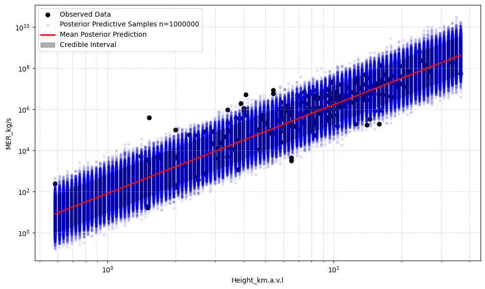

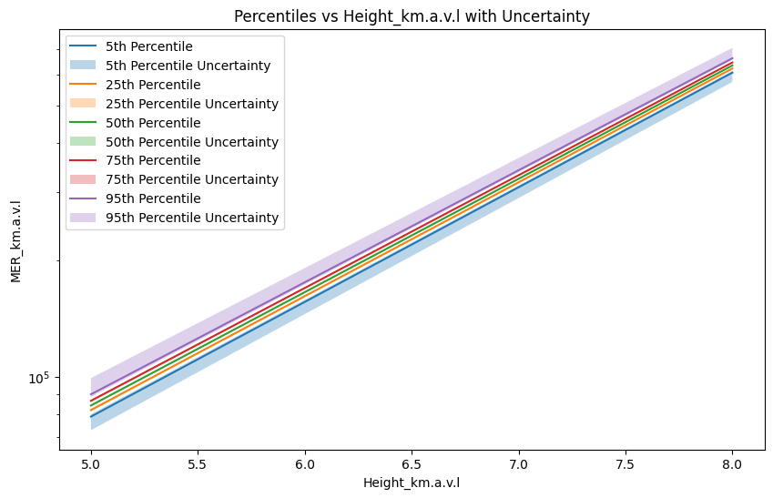

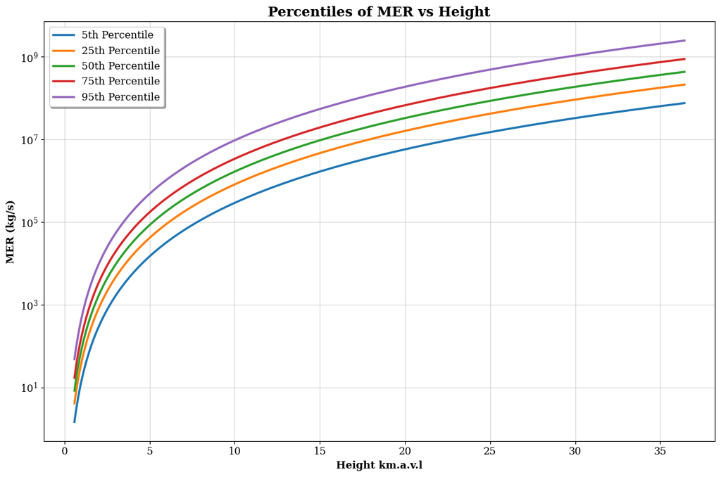

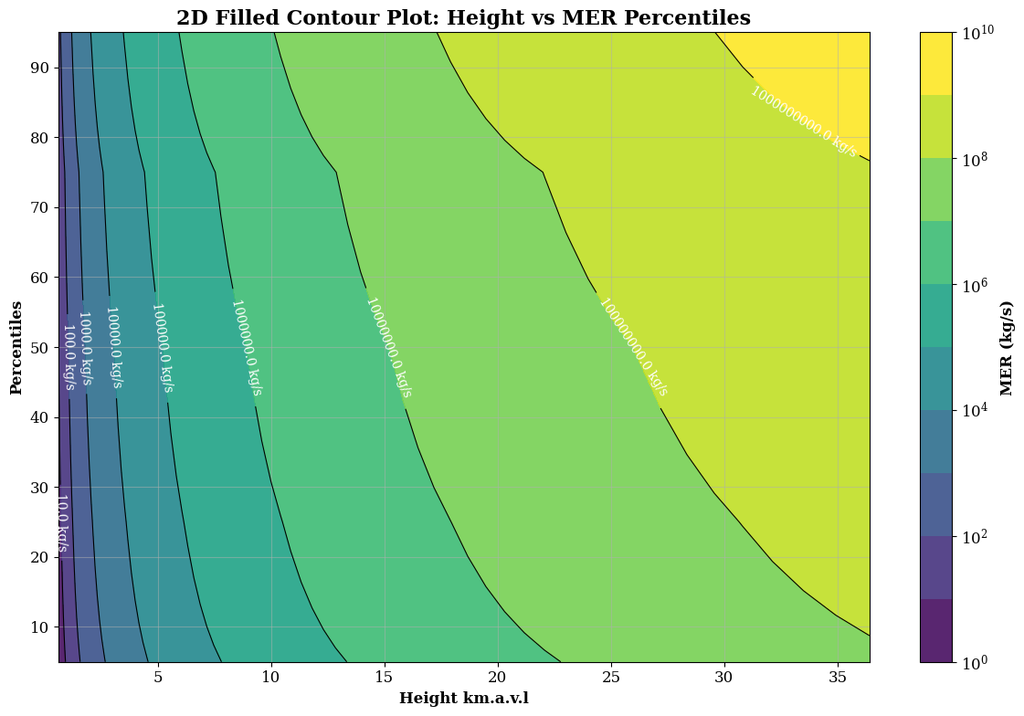

|  | Height_km.a.v.l | MERPercentile_5 | Uncertainty_Lower_5 | Uncertainty_Upper_5 | MERPercentile_25 | Uncertainty_Lower_25 | Uncertainty_Upper_25 | MERPercentile_50 | Uncertainty_Lower_50 | Uncertainty_Upper_50 | MERPercentile_75 | Uncertainty_Lower_75 | Uncertainty_Upper_75 | MERPercentile_95 | Uncertainty_Lower_95 | Uncertainty_Upper_95 | Best_MER_Estimate_km | Best_MER_Estimate_km_Uncertainty |
| --- | --- | --- | --- | --- | --- | --- | --- | --- | --- | --- | --- | --- | --- | --- | --- | --- | --- | --- |
| 0 | 5 | 78892.286871 | 72753.555476 | 80015.857555 | 82011.604587 | 81451.349253 | 82538.735752 | 84271.983168 | 83842.317081 | 84736.828325 | 86656.573911 | 86098.898191 | 87243.454000 | 90054.256717 | 88672.015678 | 99136.123217 | 11161.969846 | 19120.265661 |
| 1 | 8 | 608619.516516 | 575831.605351 | 614226.709984 | 623748.137283 | 621135.854514 | 626352.255729 | 634947.913629 | 632969.021044 | 637016.419802 | 646340.111457 | 643765.208387 | 649292.414642 | 662707.458575 | 656473.656001 | 704862.135429 | 54087.942059 | 90635.425445 |

```python
from mer_from_height import MERPredictorFromHeight

predictor = MERPredictorFromHeight(Combined_datasets)
# Predict MER for specific heights
# Save predictions to a CSV
Observed_plume_height=[5,8]
predictions=predictor.predict_MER_with_uncertainty(Observed_plume_height, output_file='predicted_mer_fromheight.csv')


# Visualize the posterior predictive distribution
predictor.plot_posterior_predictive()

# Visualize percentiles with uncertainty
predictor.plot_percentiles_with_uncertainty(Observed_plume_height)

predictor.plot_percentiles_vs_mer()

predictions
```

```
Model updated with xvar='MER_kg/s' and yvar='MER_kg/s'.
Model updated with xvar='MER_kg/s' and yvar='MASS_FRACTION_ASH_BELOW_63_micron'.
```

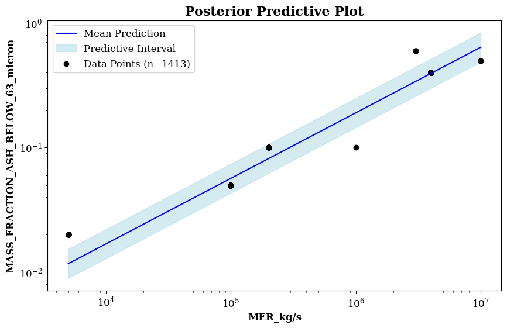

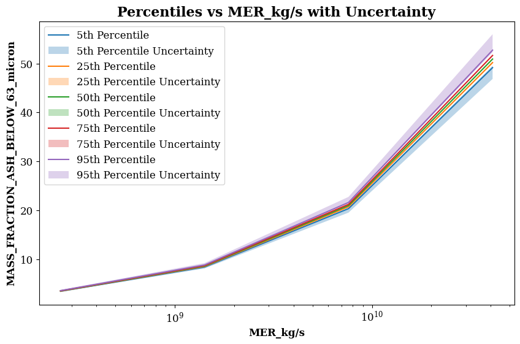

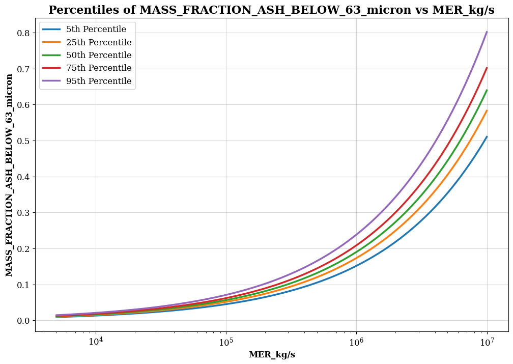

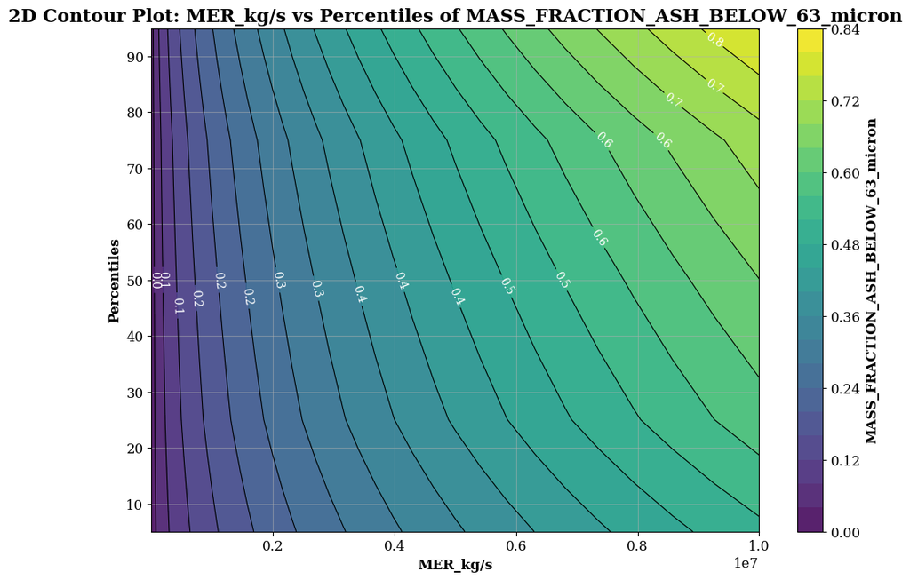

```python
from ParticleSize_MER import Predict_ASH_BELOW_63_Micron

from vei import data_loader

#mastin_a=data_loader.load_Mastin_a(as_geodataframe=True)

psize_model=Predict_ASH_BELOW_63_Micron(mastin_a)

psize_model.set_xvar('MER_kg/s')
psize_model.set_yvar('MASS_FRACTION_ASH_BELOW_63_micron')


psize_model.calculate_percentiles_with_uncertainty(mer_list)
psize_model.predict_with_uncertainty(mer_list)

psize_model.plot_posterior_predictive()


# Visualize percentiles with uncertainty
psize_model.plot_percentiles_with_uncertainty(mer_list)

psize_model.plot_percentiles()

psize_predictions=psize_model.predict_with_uncertainty(mer_list)
```

```python
psize_predictions
```

|  | MER_kg/s | MASS_FRACTION_ASH_BELOW_63_micron_Percentile_5 | Uncertainty_Lower_5 | Uncertainty_Upper_5 | MASS_FRACTION_ASH_BELOW_63_micron_Percentile_25 | Uncertainty_Lower_25 | Uncertainty_Upper_25 | MASS_FRACTION_ASH_BELOW_63_micron_Percentile_50 | Uncertainty_Lower_50 | Uncertainty_Upper_50 | MASS_FRACTION_ASH_BELOW_63_micron_Percentile_75 | Uncertainty_Lower_75 | Uncertainty_Upper_75 | MASS_FRACTION_ASH_BELOW_63_micron_Percentile_95 | Uncertainty_Lower_95 | Uncertainty_Upper_95 |
| --- | --- | --- | --- | --- | --- | --- | --- | --- | --- | --- | --- | --- | --- | --- | --- | --- |
| 0 | 2.637347e+08 | 3.510268 | 3.415337 | 3.525689 | 3.551713 | 3.544573 | 3.557974 | 3.580712 | 3.575253 | 3.586068 | 3.609362 | 3.603023 | 3.616482 | 3.651870 | 3.635538 | 3.777116 |
| 1 | 1.416006e+09 | 8.459594 | 8.174954 | 8.506458 | 8.585589 | 8.563127 | 8.604689 | 8.673290 | 8.656394 | 8.690388 | 8.760266 | 8.741047 | 8.782273 | 8.888801 | 8.839078 | 9.275573 |
| 2 | 7.603739e+09 | 20.388173 | 19.569087 | 20.524390 | 20.753400 | 20.687811 | 20.809752 | 21.009633 | 20.961152 | 21.058963 | 21.265665 | 21.208511 | 21.330891 | 21.645647 | 21.497647 | 22.780103 |
| 3 | 4.087218e+10 | 49.159041 | 46.852932 | 49.545688 | 50.194972 | 50.005336 | 50.353139 | 50.918376 | 50.783619 | 51.057364 | 51.647173 | 51.484248 | 51.832791 | 52.727763 | 52.318816 | 55.976406 |

```python
columns_to_assign=list(psize_predictions.columns)
columns_to_assign=columns_to_assign[1:]

# Assuming `columns_to_assign` contains column names and `heights` and `psize_predictions` are DataFrames

heights.loc[:, columns_to_assign] = psize_predictions[columns_to_assign]


heights.to_csv('Final_prediction_results.csv')
```

```python
psize_predictions
```

|  | MER_kg/s | MASS_FRACTION_ASH_BELOW_63_micron_Percentile_5 | Uncertainty_Lower_5 | Uncertainty_Upper_5 | MASS_FRACTION_ASH_BELOW_63_micron_Percentile_25 | Uncertainty_Lower_25 | Uncertainty_Upper_25 | MASS_FRACTION_ASH_BELOW_63_micron_Percentile_50 | Uncertainty_Lower_50 | Uncertainty_Upper_50 | MASS_FRACTION_ASH_BELOW_63_micron_Percentile_75 | Uncertainty_Lower_75 | Uncertainty_Upper_75 | MASS_FRACTION_ASH_BELOW_63_micron_Percentile_95 | Uncertainty_Lower_95 | Uncertainty_Upper_95 |
| --- | --- | --- | --- | --- | --- | --- | --- | --- | --- | --- | --- | --- | --- | --- | --- | --- |
| 0 | 2.637347e+08 | 3.510268 | 3.415337 | 3.525689 | 3.551713 | 3.544573 | 3.557974 | 3.580712 | 3.575253 | 3.586068 | 3.609362 | 3.603023 | 3.616482 | 3.651870 | 3.635538 | 3.777116 |
| 1 | 1.416006e+09 | 8.459594 | 8.174954 | 8.506458 | 8.585589 | 8.563127 | 8.604689 | 8.673290 | 8.656394 | 8.690388 | 8.760266 | 8.741047 | 8.782273 | 8.888801 | 8.839078 | 9.275573 |
| 2 | 7.603739e+09 | 20.388173 | 19.569087 | 20.524390 | 20.753400 | 20.687811 | 20.809752 | 21.009633 | 20.961152 | 21.058963 | 21.265665 | 21.208511 | 21.330891 | 21.645647 | 21.497647 | 22.780103 |
| 3 | 4.087218e+10 | 49.159041 | 46.852932 | 49.545688 | 50.194972 | 50.005336 | 50.353139 | 50.918376 | 50.783619 | 51.057364 | 51.647173 | 51.484248 | 51.832791 | 52.727763 | 52.318816 | 55.976406 |